# ISLR Chapter5 Resampling Methods

## Conceptual Excercises

1. Using basic statistical properties of the variance, as well as single variable calculus, derive (5.6)
2. Suppose that we obtain a bootstrap sample from a set of *n* observations
1. What is the probability that the first bootstrap observation is *not* the *j*th observation from the original sample?

1 - 1/n

2. What is the probability the second bootstrap observation is *not* the *j*th observation from the original sample?

3. Argue that the *j*th observation is *not* in the bootstrap sample

As bootstrapping samples with replacement each probability of *j*th not being in the bootstrapping sample is independent

(1 - 1/n)…(1 - 1/n) = (1 - 1/n)<sup>n</sup>

4. When *n* = 5, what is the probability that the *j*th observation is in the bootstrap sample?

n = 5 1 - (1 - 1/5)<sup>5</sup> = 0.67232

5. When n = 100, what is the probability that the *j*th observation is in the bootstrap sample?

n = 100 1 - (1 - 1/100)^100 = 0.6339677

6. When n = 10,000, what is probability that the *j*th observation is in the bootstrap sample

n = 10000 1 - (1 - 1/10000)^10000 = 0.632139

7. Create a plot that displays , for each integer value of *n* from 1 to 100,000, the probability that the *j*th observation is in the bootstrap sample. Comment on what you observe?

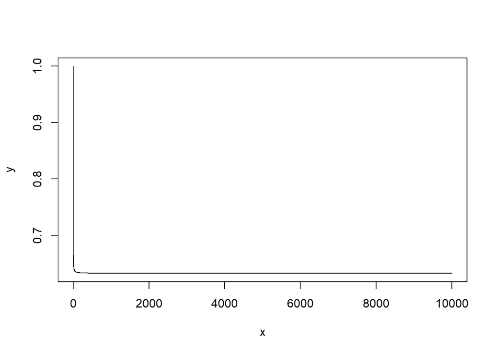

8. We will now investigate numerically the probability that a bootstrap sample of size = 100 contains the *j*th observation? Here *j* = 4. Repeatedly create bootstap samples, and each time we record whether or not the fourth observation is contained in the bootstrap sample.

```r
store = rep(NA, 10000)
for(i in 1:100000){
  store[i] = sum(sample(1:100, rep = TRUE) == 4) > 0
}

mean(store)
```

```
## [1] 0.63565
```

Confirms the previous formula

3.Reviewing the k-fold cross-validation

1. Explain how k-fold cross-validation is implemented.

Randomly divide the observations into *k* groups. Select one group as the testing set and the other groups as the training set. Calculate MSE from the observations in the testing set. Repeat process *k* times, each time using using a different group as the testing set. Average the MSE values from the *k* estimates.

2. What are the advantages and disadvantages of using *k*-fold cross-validation.
1. The validation set approach

The validation set approach uses a smaller subset of the observations the cross-validation so will likely overestimate the test error and highly variable depending on which observations used in the training set. Less computationally expensive then k-fold.

2. LOOCV

LOOCV is more computationally expensive unless fitting a model using linear or polynomial expression. LOOCV produces models with generally smaller error bias but often with a higher variance error and overall testing error.

4. Suppose that we use some statistical learning method to make a prediction for the response *Y* for a particular value of the predictor *X*. Carefully describe the how we might estimate the standard deviation of out prediction?

Estimate the standard deviation of the prediction using bootstrap. Create a function that samples data with replacement before using the data to train the statistical learning method then using the trained model to predict a value from Y from X, returning Y. Place the function into a bootstrap and repeat each time with a different subset of data being used to train the model and each time getting return on a prediction of Y from X. From the distributions of different Y predictions calculate the standard error.

## Applied Excercises

1. Fit a logistic regression model that uses income and balance to predict default
2. Use the validation set approach, estimate the test error of this model.
3. Repeat the process three times using three different splits of the obervations into atraining set and a validation set. Comment on the results obtained.

```r
library(ISLR)
library(boot)

data("Default")


# create logistic model for default using balance and income using training
# set


seed_vector <- c(1,2,3)

for(i in seed_vector){

  set.seed(i)
  train <- sample(10000, 5000)
  glm_default  <-glm(default ~ balance + income,
                   family = "binomial",
                   data = Default,
                   subset = train)

# create predictions on the testing set

  test_res <- predict(object = glm_default,
        newdata =  Default[-train,],
        type = "response")

  test_res <- ifelse(test_res >= 0.5,"Yes", "No")
  test_correct <- ifelse(test_res == Default$default[-train], TRUE, FALSE)
  print(1 - sum(test_correct) / length(test_correct))



}
```

```
## [1] 0.0254
## [1] 0.0238
## [1] 0.0264
```

Error rate changes depending on which observations are selected for the training/testing set

```r
Default$student_var <- ifelse(Default$student == "No", 0, 1)

seed_vector <- c(1,2,3)

for(i in seed_vector){

  set.seed(i)
  train <- sample(10000, 5000)
  glm_default  <-glm(default ~ balance + income + student_var,
                   family = "binomial",
                   data = Default,
                   subset = train)

# create predictions on the testing set

  test_res <- predict(object = glm_default,
        newdata =  Default[-train,],
        type = "response")

  test_res <- ifelse(test_res >= 0.5,"Yes", "No")
  test_correct <- ifelse(test_res == Default$default[-train], TRUE, FALSE)
  print(1 - sum(test_correct) / length(test_correct))



}
```

```
## [1] 0.026
## [1] 0.0246
## [1] 0.0272
```

The average test error has increased from adding student in the model.